# Support for participating in outreach and the benefits of doing so

Achintya Rao

6 August 2016

# Conclusions

# Support for outreach participation

# Benefits of outreach participation

# A bit about me

- **Science Communicator** (2010 — present)  
  Compact Muon Solenoid (CMS) Collaboration at CERN
- **Doctoral Student** (2014 — present)  
  UWE Science Communication Unit, Bristol
  - **MA in Science Journalism** (2009 — 2010)  
    City University, London
  - **BSc in Physics** (2005 — 2008)  
    St. Xavier’s College, Mumbai (Bombay)

Twitter: [@RaoOfPhysics](https://twitter.com/RaoOfPhysics) | GitHub: [@RaoOfPhysics](https://github.com/RaoOfPhysics)  
This presentation: github.com/RaoOfPhysics/201608_ICHEP

# Science Communication: Evolving Views

# Scientific Literacy

“greater knowledge about the facts of science will improve people’s lives while gaining public support for, and reducing opposition to, research”

# Public Understanding of Science and Technology

> “part of each scientist’s professional responsibility to promote the public understanding of science”

— The Royal Society, 1985, p.24

# The Deficit Model

“the role of scientists and science communicators is to fill a perceived knowledge deficit among the public”

# Low levels of Scientific Literacy

> “Many [scientists] recognise, in their own inability to be certain of their answers, that the public cannot be expected to retain facts that are not useful.”

— Stocklmayer & Bryant, 2012, p.18

# Public Engagement with Science and Technology

> “while scientists may have scientific facts at their disposal, the members of the public concerned have local knowledge and an understanding of, and personal interest in, the problems to be solved”

— Miller, 2001, p.117

# Three aspects/stages:

1. “scientists […] encouraged to inform the public”
2. “scientists […] encouraged to develop dialogue on scientific facts and processes”
3. “scientists must engage with society in the early phase of scientific development”

— Crettaz von Roten, 2011, p.54

# Science Communication research

- Conversation dominated with research fields that have:
  - direct impact
  - immediate impact
- What about fundamental research?

# My PhD project

# “Engagement” → “Outreach”

- used to refer to all science-communication activities “designed for an audience outside academia” (Crettaz von Roten, 2011, p.54)
- used among particle physicists to refer to:
  - working with schools
  - direct dialogue with the public
  - disseminating information through the media

> The term “outreach” refers to all science communication and education activities that bring scientific research to audiences outside the research community. It is also known as “popularisation”.

— note included in survey

# Research questions

- What are the attitudes towards outreach within the particle-physics community and what are the motivations for and barriers against participating
- Do these vary w.r.t. age, gender and academic position

# Research questions (…)

- How are these influenced by
  - funding bodies
  - national expectations towards outreach
  - the multicultural nature of international collaborations
- How does the community perceive the usefulness and impact of outreach

### [CERN](http://home.cern)

The European Laboratory for Particle Physics

- Geneva, Switzerland
- host laboratory for international collaborations
- ~half of all 20,000 particle physicists

### The CMS Collaboration

[**C**ompact **M**uon **S**olenoid](http://cms.web.cern.ch)

- one of the two teams that [discovered the Higgs boson in 2012](http://cms.web.cern.ch/news/observation-new-particle-mass-125-gev)
- people (June 2015)
  - over 4000 physicists, engineers, students (not including technicians and admin)
  - 183 institutes, universities, laboratories from 42 countries
  - 80+ nationalities

# Data collection for quantitative analysis

# Electronic survey distributed by e-mail

- Sent to the whole collaboration via mailing list
- Three reminders sent to whole list
- Engineers reminded separately as well
- Representatives from low-response countries reminded separately

# Responses

- over 400, but a few duplicates
- final count: **391** valid responses
- ~10% of the collaboration

# CMS member countries

[interactive chart not shown]

# Participation in outreach

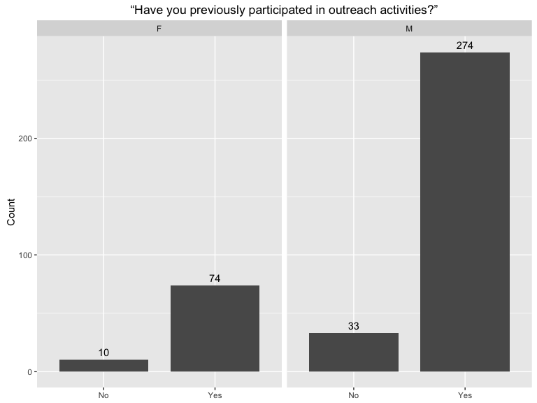

# Support for outreach participation

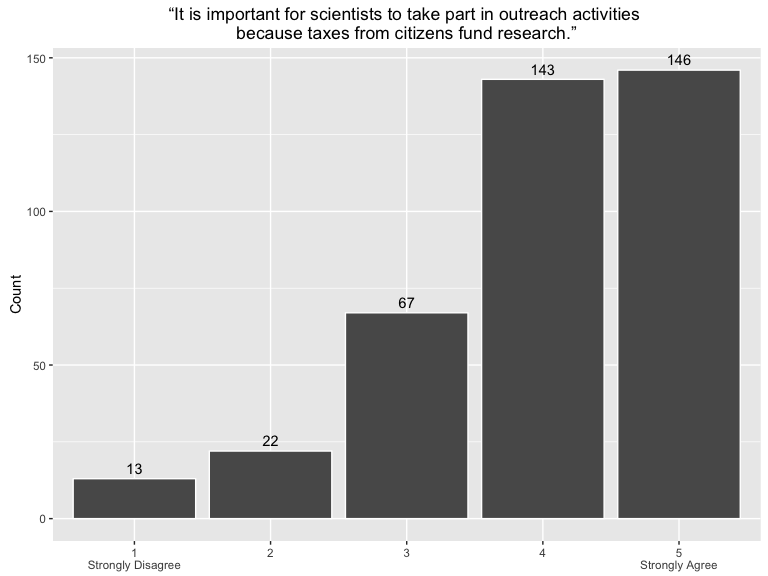

*… outreach is important because research is supported by taxes…*

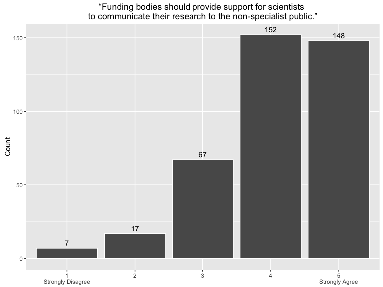

*… funding bodies should scientists help do outreach…*

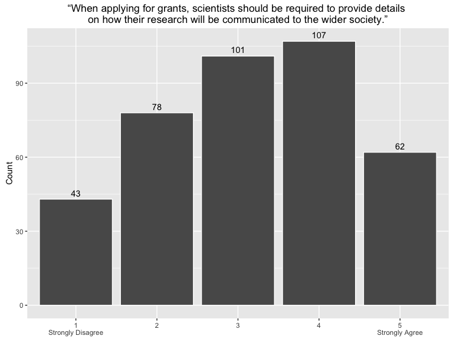

*… outreach details included in grant applications…*

[figure not shown]

# Benefits of outreach participation

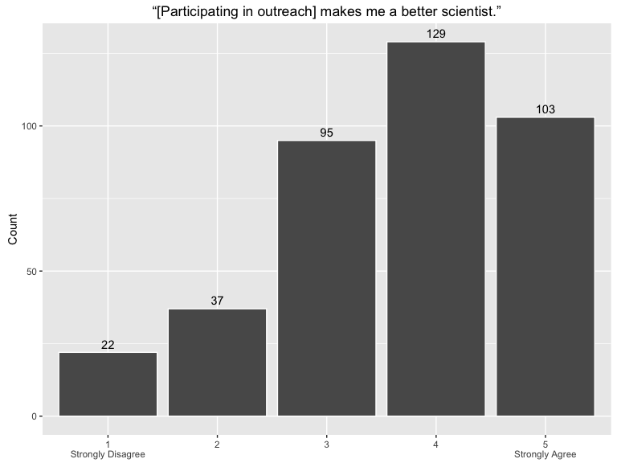

*… makes me a better scientist…*

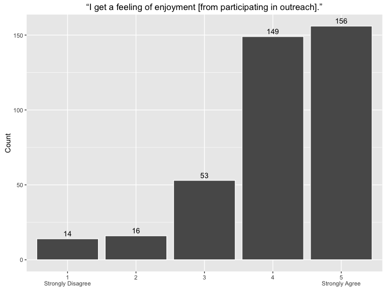

*… feeling of enjoyment…*

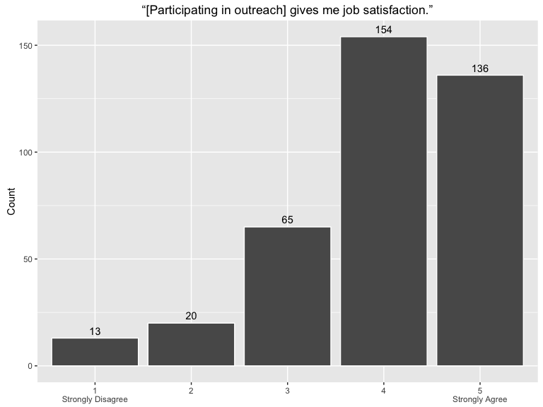

*… job satisfaction…*

[figure not shown]

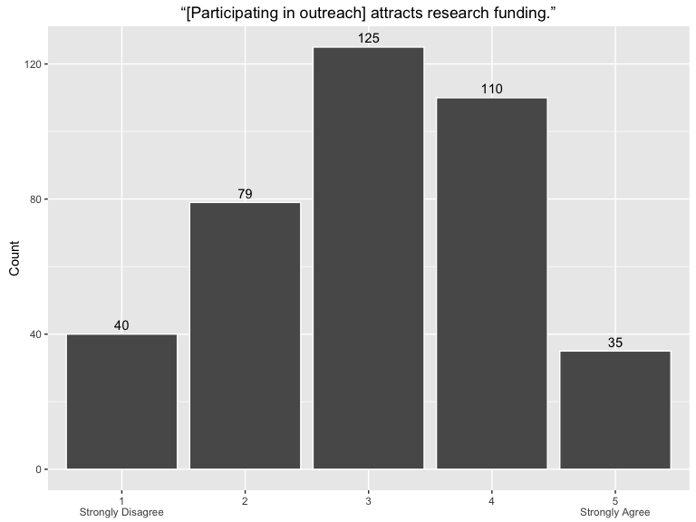

*… attracts research funding…*

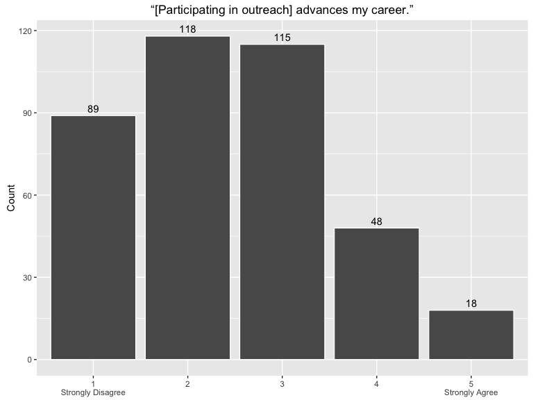

*… advances my career…*

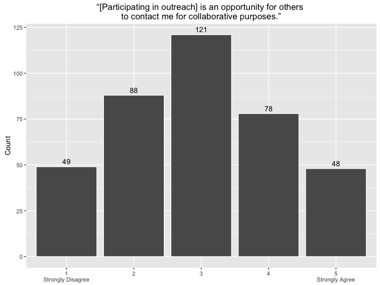

*… collaboration opportunities…*

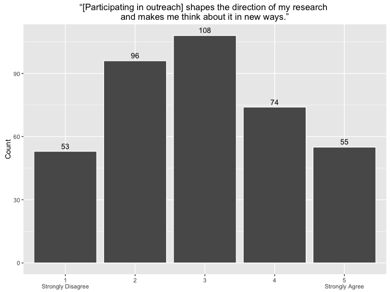

*… think of my research in new ways…*

# Conclusions

# Support for outreach participation

# Benefits of outreach participation

# Acknowledgements

Emma Weitkamp, Clare Wilkinson, Erik Stengler, Christine Sutton, for supervising my research

Achille Petrilli, CMS Head of Communications, for supporting my research

Special thanks to Richard Smith-Unna (t: [@blahah404](https://twitter.com/blahah404)) for help with R code!

[R](https://www.r-project.org/) + [RStudio](https://www.rstudio.com/)

[reveal.js](http://lab.hakim.se/reveal-js/)

[plotly](https://plot.ly/)

[RAW](http://raw.densitydesign.org/)

[Git](https://git-scm.com/) + [GitHub](https://github.com/)